# Семинар 3. Кластерный анализ

May 31, 2018

Признаемся: часть сокровищ R мы утаили :)

Много пакетов R можно поставить с официального репозитория CRAN через `Tools` - `Install packages`. Однако несметные богатства пакетов лежат на github! Сайт rdrr.io позволяет искать сокровища :)

О новых прикольных пакетах обычно рассказывают на r-bloggers.com.

Чтобы поставить пакет нужно знать имя разработчика и название пакета. Мы поставим пакет `patchwork` от `thomasp85`. Томас придумал простой язык, чтобы рисовать несколько графиков рядом.

Ставим пакет Томаса:

```r
devtools::install_github('thomasp85/patchwork')
```

Как правило, разработчики интригующе описывают пакет прямо на гитхабе. Например, описание пакета [у Томаса](https://github.com/thomasp85/patchwork).

Установка выполняется один раз :)

Теперь подключаем пакеты!

```r
library(tidyverse) # обработка данных, графики...
library(skimr)# описательные статистики
library(rio) # импорт фантастического количества форматов данных
library(cluster) # кластерный анализ
library(factoextra) # визуализации kmeans, pca,
library(dendextend) # визуализация дендрограмм
```

```r
library(corrplot) # визуализация корреляций
library(broom) # метла превращает результаты оценивания моделей в таблички
library(naniar) # визуализация пропущенных значений
library(visdat) # визуализация пропущенных значений

library(patchwork) # удобное расположение графиков рядом

library(nycflights13) # данные о полётах в Нью-Йорке
```

# 1 Основные классы данных

В R несколько разных классов данных:

- вектора
- таблички
- матрицы
- списки
- ещё куча всего

### 1.0.1 Векторы

Создадим несколько векторов с пропущенными значениями!

```r
a <- c(5, 6, 7, NA, 8)
b <- 11:15
b
```

```
## [1] 11 12 13 14 15
```

- Что находится в векторе `b`?

С числовыми векторами работают школьные функции:

```r
max(b)
```

```
## [1] 15
```

```r
max(a)
```

```
## [1] NA
```

```r
max(a, na.rm = TRUE)
```

```
## [1] 8
```

```r
mean(a)
```

```
## [1] NA
```

```r
mean(a, na.rm = TRUE)
```

```
## [1] 6.5
```

- Чем отличаются функции `max(a)` и `max(a, na.rm = TRUE)`?

### 1.0.2 Таблички

Таблицы можно создавать самим c помощью функции `tibble()`.

```r
mx <- tibble(ID = c('A', 'B', 'C', 'D', 'E'),
           x = c(1, 2, 4, 1, 8))
mx
```

```
## # A tibble: 5 x 2
##   ID        x
##   <chr> <dbl>
## 1 A         1
## 2 B         2
## 3 C         4
## 4 D         1
## 5 E         8
```

- Упражнение 1.

Создайте таблицу `my`, с двумя столбцами: `ID` и `y`, и пятью значениями в каждом. Столбец `y` можно заполнить числами произвольно.

```r
my <- tibble(ID = c('A', 'C', 'D', 'F', 'E'),
             y = c(1, 2, -3, 4, -5))
my
```

```
## # A tibble: 5 x 2
##   ID        y
##   <chr> <dbl>
## 1 A         1
## 2 C         2
## 3 D        -3
## 4 F         4
## 5 E        -5
```

### 1.0.3 Матрицы

Матрицы очень похожи на таблицы. Их основное отличие в том, что в них могут быть только числа. С матрицами работают люди, которым нужна ну очень высокая скорость. Мы будем работать только с таблицами.

```r
my_matrix <- matrix(c(1, 2, 3, 4, 5, 6), nrow = 2)
my_matrix
```

```
##      [,1] [,2] [,3]
## [1,]    1    3    5
## [2,]    2    4    6
```

```r
class(my_matrix)
```

```
## [1] "matrix"
```

А если нам вдруг встретится злобная, но ценная матрица, мы её тут же преобразуем в таблицу.

```r
skim(my_matrix) # не работает :(
```

```
## No skim method exists for class matrix.
```

```r
my_tibble <- as_tibble(my_matrix)
skim(my_tibble)
```

```
## Skim summary statistics
##  n obs: 2
##  n variables: 3
```

```
##
## Variable type: numeric
##  variable missing complete n mean   sd p0  p25 p50  p75 p100     hist
##        V1       0        2 2  1.5 0.71  1 1.25 1.5 1.75    2 ▇▁▁▁▁▁▁▇
##        V2       0        2 2  3.5 0.71  3 3.25 3.5 3.75    4 ▇▁▁▁▁▁▁▇
##        V3       0        2 2  5.5 0.71  5 5.25 5.5 5.75    6 ▇▁▁▁▁▁▁▇
```

### 1.0.4 Списки

Список - это чулан, в котором может быть полно ценных вещей. В списке может храниться всё что угодно. Как правило в списках хранятся результаты оценивания сложных моделей.

```r
my_list <- list(kreks = 'Привет!', peks = c(5, 6, NA), feks = diamonds)
my_list$kreks
```

```
## [1] "Привет!"
```

```r
my_list$peks
```

```
## [1]  5  6 NA
```

```r
attributes(my_list)
```

```
## $names
## [1] "kreks" "peks"  "feks"
```

Узнать, что лежит в чулане-списке, можно либо с помощью функции `attributes`, либо нажав на значок лупы во вкладке `Environment` в Rstudio. Обычно вкладка `Environment` справа вверху.

# 2 Соединение таблиц

Таблицы можно соединять! Существует четыре способа сделать это: - `left_join(x, y, by = 'colname')` сохраняет все наблюдения в таблице `x` - `right_join(x, y, by = 'colname')` сохраняет все наблюдения в таблице `y` - `full_join(x, y, by = 'colname')` сохраняет наблюдения из обеих таблиц - `inner_join(x, y, by = 'colname')` объединяет только те строки обеих таблиц, в которых нет пропущенных наблюдений

- Упражнение 2.

Экспериментируем!

```r
left_join(mx, my, by = 'ID')
```

```
## # A tibble: 5 x 3
##   ID        x     y
##   <chr> <dbl> <dbl>
## 1 A         1     1
## 2 B         2    NA
## 3 C         4     2
## 4 D         1    -3
## 5 E         8    -5
```

```r
right_join(mx, my, by = 'ID')
```

```
## # A tibble: 5 x 3
##   ID        x     y
##   <chr> <dbl> <dbl>
## 1 A         1     1
## 2 C         4     2
## 3 D         1    -3
## 4 F        NA     4
## 5 E         8    -5
```

```r
inner_join(mx, my, by = 'ID')
```

```
## # A tibble: 4 x 3
##   ID        x     y
##   <chr> <dbl> <dbl>
## 1 A         1     1
## 2 C         4     2
## 3 D         1    -3
## 4 E         8    -5
```

```r
full_join(mx, my, by = 'ID')
```

```
## # A tibble: 6 x 3
##   ID        x     y
##   <chr> <dbl> <dbl>
## 1 A         1     1
## 2 B         2    NA
## 3 C         4     2
## 4 D         1    -3
## 5 E         8    -5
## 6 F        NA     4
```

- Сколько наблюдений получается в объединённой таблице в каждом случае?
- Упражнение 3.

Нужно объединить таблицы `flights` и `weather` о вылетах из Нью-Йорка сразу по нескольким столбцам!

- ‘Бросьте взгляд’ на обе таблицы. Какие столбцы совпадают?

```r
glimpse(flights)
```

```
## Observations: 336,776
## Variables: 19
```

```
## $ year           <int> 2013, 2013, 2013, 2013, 2013, 2013, 2013, 2013,...
## $ month          <int> 1, 1, 1, 1, 1, 1, 1, 1, 1, 1, 1, 1, 1, 1, 1, 1,...
## $ day            <int> 1, 1, 1, 1, 1, 1, 1, 1, 1, 1, 1, 1, 1, 1, 1, 1,...
## $ dep_time       <int> 517, 533, 542, 544, 554, 554, 555, 557, 557, 55...
## $ sched_dep_time <int> 515, 529, 540, 545, 600, 558, 600, 600, 600, 60...
## $ dep_delay      <dbl> 2, 4, 2, -1, -6, -4, -5, -3, -3, -2, -2, -2, -2...
## $ arr_time       <int> 830, 850, 923, 1004, 812, 740, 913, 709, 838, 7...
## $ sched_arr_time <int> 819, 830, 850, 1022, 837, 728, 854, 723, 846, 7...
## $ arr_delay      <dbl> 11, 20, 33, -18, -25, 12, 19, -14, -8, 8, -2, -...
## $ carrier        <chr> "UA", "UA", "AA", "B6", "DL", "UA", "B6", "EV",...
## $ flight         <int> 1545, 1714, 1141, 725, 461, 1696, 507, 5708, 79...
## $ tailnum        <chr> "N14228", "N24211", "N619AA", "N804JB", "N668DN...
## $ origin         <chr> "EWR", "LGA", "JFK", "JFK", "LGA", "EWR", "EWR"...
## $ dest           <chr> "IAH", "IAH", "MIA", "BQN", "ATL", "ORD", "FLL"...
## $ air_time       <dbl> 227, 227, 160, 183, 116, 150, 158, 53, 140, 138...
## $ distance       <dbl> 1400, 1416, 1089, 1576, 762, 719, 1065, 229, 94...
## $ hour           <dbl> 5, 5, 5, 5, 6, 5, 6, 6, 6, 6, 6, 6, 6, 6, 6, 5,...
## $ minute         <dbl> 15, 29, 40, 45, 0, 58, 0, 0, 0, 0, 0, 0, 0, 0, ...
## $ time_hour      <dttm> 2013-01-01 05:00:00, 2013-01-01 05:00:00, 2013...
```

```r
glimpse(weather)
```

```
## Observations: 26,130
## Variables: 15
## $ origin     <chr> "EWR", "EWR", "EWR", "EWR", "EWR", "EWR", "EWR", "E...
## $ year       <dbl> 2013, 2013, 2013, 2013, 2013, 2013, 2013, 2013, 201...
## $ month      <dbl> 1, 1, 1, 1, 1, 1, 1, 1, 1, 1, 1, 1, 1, 1, 1, 1, 1, ...
## $ day        <int> 1, 1, 1, 1, 1, 1, 1, 1, 1, 1, 1, 1, 1, 1, 1, 1, 1, ...
## $ hour       <int> 0, 1, 2, 3, 4, 6, 7, 8, 9, 10, 11, 12, 13, 14, 15, ...
## $ temp       <dbl> 37.04, 37.04, 37.94, 37.94, 37.94, 39.02, 39.02, 39...
## $ dewp       <dbl> 21.92, 21.92, 21.92, 23.00, 24.08, 26.06, 26.96, 28...
## $ humid      <dbl> 53.97, 53.97, 52.09, 54.51, 57.04, 59.37, 61.63, 64...
## $ wind_dir   <dbl> 230, 230, 230, 230, 240, 270, 250, 240, 250, 260, 2...
## $ wind_speed <dbl> 10.35702, 13.80936, 12.65858, 13.80936, 14.96014, 1...
## $ wind_gust  <dbl> 11.918651, 15.891535, 14.567241, 15.891535, 17.2158...
## $ precip     <dbl> 0, 0, 0, 0, 0, 0, 0, 0, 0, 0, 0, 0, 0, 0, 0, 0, 0, ...
## $ pressure   <dbl> 1013.9, 1013.0, 1012.6, 1012.7, 1012.8, 1012.0, 101...
## $ visib      <dbl> 10, 10, 10, 10, 10, 10, 10, 10, 10, 10, 10, 10, 10,...
## $ time_hour  <dttm> 2013-01-01 00:00:00, 2013-01-01 01:00:00, 2013-01-...
```

- Присоедините к таблице `flights` таблицу `weather` с помощью функции `left_join()`. В качестве аргумента `by` используйте вектор из названий общих столбцов: `year`, `month`, `day`, `hour` и `origin`.
- Сколько наблюдений в объединённой таблице?

```r
left <- left_join(flights, weather, by = c('year', 'month', 'day', 'hour', 'origin'))
glimpse(left)
```

```
## Observations: 336,776
## Variables: 29
## $ year           <dbl> 2013, 2013, 2013, 2013, 2013, 2013, 2013, 2013,...
## $ month          <dbl> 1, 1, 1, 1, 1, 1, 1, 1, 1, 1, 1, 1, 1, 1, 1, 1,...
## $ day            <int> 1, 1, 1, 1, 1, 1, 1, 1, 1, 1, 1, 1, 1, 1, 1, 1,...
## $ dep_time       <int> 517, 533, 542, 544, 554, 554, 555, 557, 557, 55...
## $ sched_dep_time <int> 515, 529, 540, 545, 600, 558, 600, 600, 600, 60...
## $ dep_delay      <dbl> 2, 4, 2, -1, -6, -4, -5, -3, -3, -2, -2, -2, -2...
## $ arr_time       <int> 830, 850, 923, 1004, 812, 740, 913, 709, 838, 7...
## $ sched_arr_time <int> 819, 830, 850, 1022, 837, 728, 854, 723, 846, 7...
## $ arr_delay      <dbl> 11, 20, 33, -18, -25, 12, 19, -14, -8, 8, -2, -...
## $ carrier        <chr> "UA", "UA", "AA", "B6", "DL", "UA", "B6", "EV",...
## $ flight         <int> 1545, 1714, 1141, 725, 461, 1696, 507, 5708, 79...
## $ tailnum        <chr> "N14228", "N24211", "N619AA", "N804JB", "N668DN...
## $ origin         <chr> "EWR", "LGA", "JFK", "JFK", "LGA", "EWR", "EWR"...
```

[output cut: 16 more lines]

- Повторите соединение двух таблиц, но используя `inner_join()`. Сколько наблюдений в получившейся таблице?
- В чём разница `left_join` и `inner_join`?

```r
inner <- inner_join(flights, weather, by = c('year', 'month', 'day', 'hour', 'origin'))
glimpse(inner)
```

```
## Observations: 335,563
## Variables: 29
## $ year           <dbl> 2013, 2013, 2013, 2013, 2013, 2013, 2013, 2013,...
## $ month          <dbl> 1, 1, 1, 1, 1, 1, 1, 1, 1, 1, 1, 1, 1, 1, 1, 1,...
## $ day            <int> 1, 1, 1, 1, 1, 1, 1, 1, 1, 1, 1, 1, 1, 1, 1, 1,...
## $ dep_time       <int> 554, 555, 557, 557, 558, 558, 558, 558, 558, 55...
## $ sched_dep_time <int> 600, 600, 600, 600, 600, 600, 600, 600, 600, 60...
## $ dep_delay      <dbl> -6, -5, -3, -3, -2, -2, -2, -2, -2, -1, -1, 0, ...
## $ arr_time       <int> 812, 913, 709, 838, 753, 849, 853, 924, 923, 94...
## $ sched_arr_time <int> 837, 854, 723, 846, 745, 851, 856, 917, 937, 91...
## $ arr_delay      <dbl> -25, 19, -14, -8, 8, -2, -3, 7, -14, 31, -8, -7...
## $ carrier        <chr> "DL", "B6", "EV", "B6", "AA", "B6", "B6", "UA",...
## $ flight         <int> 461, 507, 5708, 79, 301, 49, 71, 194, 1124, 707...
## $ tailnum        <chr> "N668DN", "N516JB", "N829AS", "N593JB", "N3ALAA...
## $ origin         <chr> "LGA", "EWR", "LGA", "JFK", "LGA", "JFK", "JFK"...
```

[output cut: 16 more lines]

# 3 Длинные и широкие таблицы

Таблицы бывают длинными и широкими! При поступлении нового наблюдения длинная растёт в длину, а широкая может и в ширину :)

Возьмём квартальные данные [Росстата](http://www.gks.ru/free_doc/new_site/vvp/kv/tab35.htm) о ВВП по источникам доходов.

```r
gdp <- import('gdp.xls')
glimpse(gdp)
```

```
## Observations: 4
## Variables: 29
## $ X__1             <chr> "Валовой внутренний продукт", "оплата труда н...
## $ `1 квартал 2011` <dbl> 13028.844, 6055.775, 1807.421, 5165.648
## $ `2 квартал 2011` <dbl> 14481.142, 6469.798, 2205.521, 5805.824
## $ `3 квартал 2011` <dbl> 15805.582, 6678.376, 2280.732, 6846.474
## $ `4 квартал 2011` <dbl> 16966.973, 7182.727, 2453.331, 7330.951
## $ `1 квартал 2012` <dbl> 15182.987, 6991.065, 2194.436, 5997.486
## $ `2 квартал 2012` <dbl> 16472.215, 7448.678, 2582.311, 6441.226
## $ `3 квартал 2012` <dbl> 17733.545, 7615.371, 2423.306, 7694.848
## $ `4 квартал 2012` <dbl> 18775.136, 8146.048, 2630.635, 7998.463
## $ `1 квартал 2013` <dbl> 16375.261, 7828.690, 2335.080, 6211.491
## $ `2 квартал 2013` <dbl> 17538.839, 8350.152, 2572.417, 6616.269
## $ `3 квартал 2013` <dbl> 19058.114, 8569.038, 2522.510, 7966.566
## $ `4 квартал 2013` <dbl> 20161.681, 9044.402, 2632.313, 8484.967
```

[output cut: 16 more lines]

```r
gdp
```

```
##                                                                                                                         X__1
## 1                                                                                                 Валовой внутренний продукт
## 2 оплата труда наемных работников (включая оплату труда и смешанные доходы, не наблюдаемые прямыми статистическими методами)
## 3                                                                                     чистые налоги на производство и импорт
## 4                                                                       валовая прибыль экономики и валовые смешанные доходы
##   1 квартал 2011 2 квартал 2011 3 квартал 2011 4 квартал 2011
## 1      13028.844      14481.142      15805.582      16966.973
## 2       6055.775       6469.798       6678.376       7182.727
## 3       1807.421       2205.521       2280.732       2453.331
## 4       5165.648       5805.824       6846.474       7330.951
##   1 квартал 2012 2 квартал 2012 3 квартал 2012 4 квартал 2012
## 1      15182.987      16472.215      17733.545      18775.136
## 2       6991.065       7448.678       7615.371       8146.048
## 3       2194.436       2582.311       2423.306       2630.635
## 4       5997.486       6441.226       7694.848       7998.463
```

[output cut: 25 more lines]

Обнаружив неудачное название переменной переименуем её сразу!

```r
gdp <- rename(gdp, indicator = X__1)
```

Чтобы превратить широкую таблицу в длинную, нужна функция `gather()` из пакета `tidyr`.

В длинной таблице мы создадим два новых столбца: - столбец `date` с названиями старых столбцов - столбец `quantity` со значениями таблицы

Если столбец `indicator` нужно оставить как есть, упоминаем его с минусом!

```r
long_gdp <- gather(gdp, key = 'date', value = 'quantity', -indicator)
glimpse(long_gdp)
```

```
## Observations: 112
## Variables: 3
## $ indicator <chr> "Валовой внутренний продукт", "оплата труда наемных ...
## $ date      <chr> "1 квартал 2011", "1 квартал 2011", "1 квартал 2011"...
## $ quantity  <dbl> 13028.844, 6055.775, 1807.421, 5165.648, 14481.142, ...
```

Создадим типичную длинную таблицу! Например, для каждого качества огранки `cut` и цвета `color` посчитаем медиану цены:

```r
diamonds_med <- group_by(diamonds, cut, color) %>%
  summarise(med_price = median(price))
diamonds_med
```

```
## # A tibble: 35 x 3
## # Groups:   cut [?]
##    cut   color med_price
##    <ord> <ord>     <dbl>
##  1 Fair  D         3730
##  2 Fair  E         2956
##  3 Fair  F         3035
##  4 Fair  G         3057
##  5 Fair  H         3816
##  6 Fair  I         3246
##  7 Fair  J         3302
##  8 Good  D         2728.
##  9 Good  E         2420
## 10 Good  F         2647
## # ... with 25 more rows
```

А теперь превратим её в широкую:

```r
diamonds_wide <- spread(diamonds_med, key = 'color', value = 'med_price')
diamonds_wide
```

```
## # A tibble: 5 x 8
## # Groups:   cut [5]
##   cut           D     E     F     G     H     I     J
##   <ord>     <dbl> <dbl> <dbl> <dbl> <dbl> <dbl> <dbl>
## 1 Fair      3730  2956   3035 3057  3816  3246   3302
## 2 Good      2728. 2420   2647 3340  3468. 3640.  3733
## 3 Very Good 2310  1990.  2471 2437  3734  3888   4113
## 4 Premium   2009  1928   2841 2745  4511  4640   5063
## 5 Ideal     1576  1437   1775 1858. 2278  2659   4096
```

Здесь тупому компьютеру умный Homo Sapiens укажет: - какая переменная станет столбцами новой таблицы: `color` - какая переменная пойдёт внутрь таблицы: `med_price`

Не упомянутые переменные останутся строками новой широкой таблицы.

- Упражнение 4.

Из данных про воздух в Нью-Йорке `airquality` сделайте длинную таблицу. В качестве сохраняемых столбцов возьмите переменные `Month` и `Day`.

```r
air_long <- gather(airquality, key = 'indicator', value = 'value', -Month, -Day)
air_long
```

```
##     Month Day indicator value
## 1       5   1     Ozone  41.0
## 2       5   2     Ozone  36.0
## 3       5   3     Ozone  12.0
## 4       5   4     Ozone  18.0
## 5       5   5     Ozone    NA
## 6       5   6     Ozone  28.0
## 7       5   7     Ozone  23.0
## 8       5   8     Ozone  19.0
## 9       5   9     Ozone   8.0
## 10      5  10     Ozone    NA
## 11      5  11     Ozone   7.0
## 12      5  12     Ozone  16.0
## 13      5  13     Ozone  11.0
## 14      5  14     Ozone  14.0
```

[output cut: 598 more lines]

- Как называются столбцы в длинной таблице? Что в них находится?

А из получившейся длинной таблицы восстановите исходную!

```r
air_wide <- spread(air_long, key = 'indicator', value = 'value')
air_wide
```

```
##     Month Day Ozone Solar.R Temp Wind
## 1       5   1    41     190   67  7.4
## 2       5   2    36     118   72  8.0
## 3       5   3    12     149   74 12.6
## 4       5   4    18     313   62 11.5
## 5       5   5    NA      NA   56 14.3
## 6       5   6    28      NA   66 14.9
## 7       5   7    23     299   65  8.6
## 8       5   8    19      99   59 13.8
## 9       5   9     8      19   61 20.1
## 10      5  10    NA     194   69  8.6
## 11      5  11     7      NA   74  6.9
## 12      5  12    16     256   69  9.7
## 13      5  13    11     290   66  9.2
## 14      5  14    14     274   68 10.9
```

[output cut: 139 more lines]

# 4 Работа с пропущенными данными :)

Команда `skim()` для описательных статистик показывает число пропущенных наблюдений в каждой перменной. Оказывается, их тоже можно визуализировать! Для этого будем использовать пакеты `naniar` и `visdat`. Посмотрим на пропущенные значения в сгенирированных данных `typical_data` командой `vis_miss()`. Сначала не будем добавлять аргументы, а затем сгруппируем пропуски с помощью иерархической кластеризации аргументом `cluster = TRUE`.

```r
skim(typical_data)
```

```
## Skim summary statistics
##  n obs: 5000
##  n variables: 9
##
## Variable type: character
##  variable missing complete    n min max empty n_unique
##        ID    1000     4000 5000   4   4     0     4000
##
## Variable type: factor
##  variable missing complete    n n_unique
##      Race       0     5000 5000        8
##       Sex       0     5000 5000        2
##                               top_counts ordered
##  Whi: 3196, His: 811, Bla: 612, Asi: 244   FALSE
##              Mal: 2500, Fem: 2500, NA: 0   FALSE
##
## Variable type: integer
##  variable missing complete    n  mean   sd p0 p25 p50 p75 p100     hist
##       Age    1000     4000 5000 27.47 4.58 20  24  27  31   35 ▇▇▇▇▇▇▇▇
##
## Variable type: logical
##  variable missing complete    n mean                       count
##      Died       0     5000 5000 0.5  FAL: 2518, TRU: 2482, NA: 0
##    Smokes       0     5000 5000 0.18  FAL: 4088, TRU: 912, NA: 0
##
## Variable type: numeric
##    variable missing complete    n     mean       sd     p0      p25
##  Height(cm)       0     5000 5000   175.31     9.73 141.2    168.6
##      Income    1000     4000 5000 40070.95 28533.8  403.77 19316.84
##          IQ    1000     4000 5000    99.76    10.09  63       93
##       p50      p75      p100     hist
##    175.5    182.1     212    ▁▁▅▇▇▃▁▁
##  33128.29 53667.62 208210.62 ▇▇▃▂▁▁▁▁
##    100      107       135    ▁▁▃▇▇▅▁▁
```

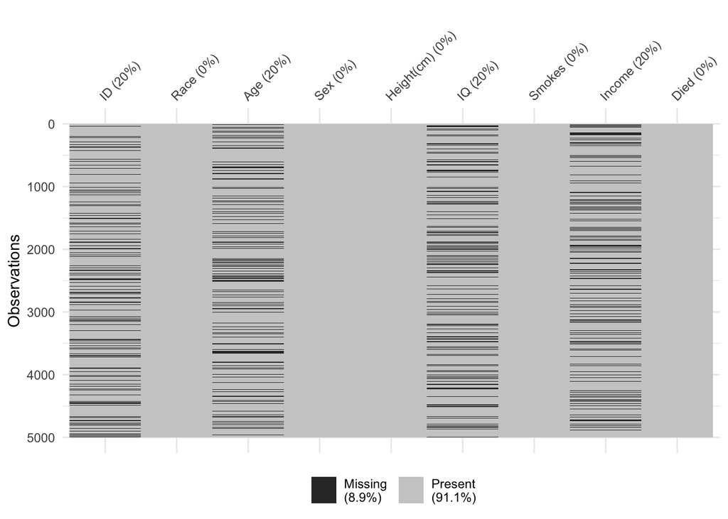

```r
vis_miss(typical_data)
```

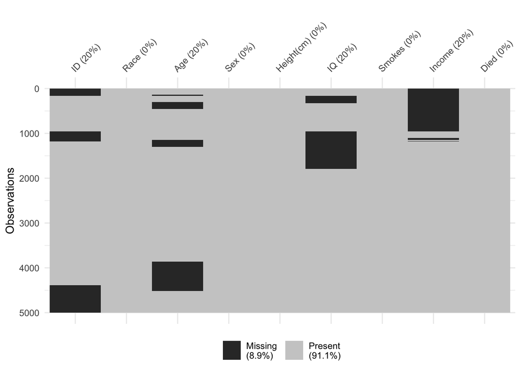

```r
vis_miss(typical_data, cluster = TRUE)
```

- Упражнение 5.

Визуализируйте пропуски во встроенных данных о воздухе в Нью-Йорке `airquality`, сгруппировав их по кластерам.

```r
skim(airquality)
```

```
## Skim summary statistics
##  n obs: 153
##  n variables: 6
##
## Variable type: integer
##  variable missing complete   n   mean    sd p0    p25   p50    p75 p100
##       Day       0      153 153  15.8   8.86  1   8     16    23      31
##     Month       0      153 153   6.99  1.42  5   6      7     8       9
##     Ozone      37      116 153  42.13 32.99  1  18     31.5  63.25  168
##   Solar.R       7      146 153 185.93 90.06  7 115.75 205   258.75  334
##      Temp       0      153 153  77.88  9.47 56  72     79    85      97
##      hist
##  ▇▇▇▇▆▇▇▇
##  ▇▇▁▇▁▇▁▇
##  ▇▆▃▃▂▁▁▁
##  ▃▃▃▃▅▇▇▃
##  ▂▂▃▆▇▇▃▃
##
## Variable type: numeric
##  variable missing complete   n  mean   sd  p0 p25 p50  p75 p100     hist
##      Wind       0      153 153  9.96 3.52 1.7 7.4 9.7 11.5 20.7 ▁▃▇▇▅▅▁▁
```

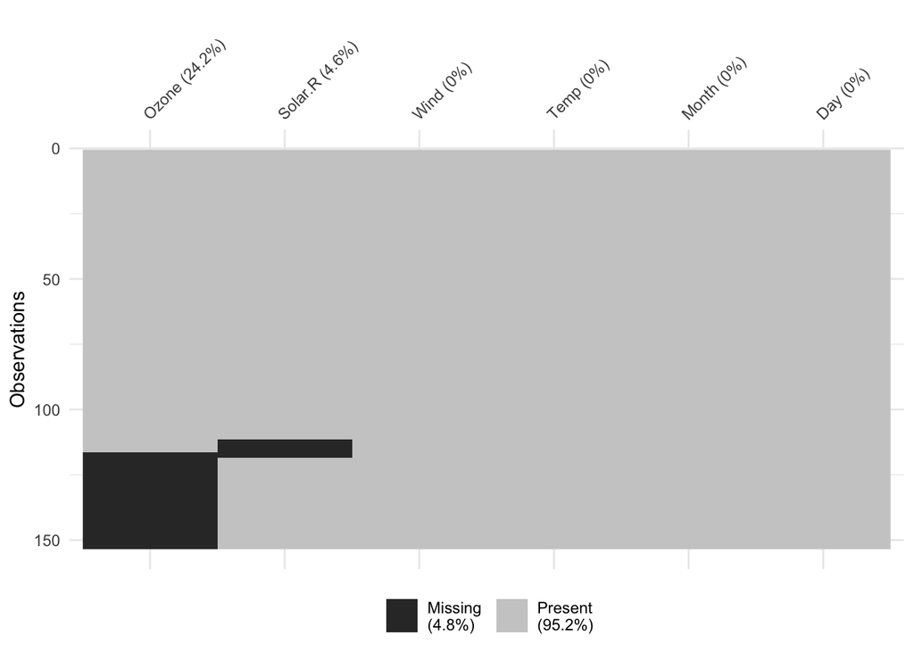

```r
vis_miss(airquality, cluster = TRUE)
```

- Какие признаки содержат пропущенные наблюдения?
- Какова доля пропусков в данных `airquality`?

Команда `gg_miss_var()` также позволяет посмотореть на количество пропущенных значений. По умолчанию пропуски считаются в абсолютных значениях, заказать проценты можно аргументом `show_pct = TRUE`.

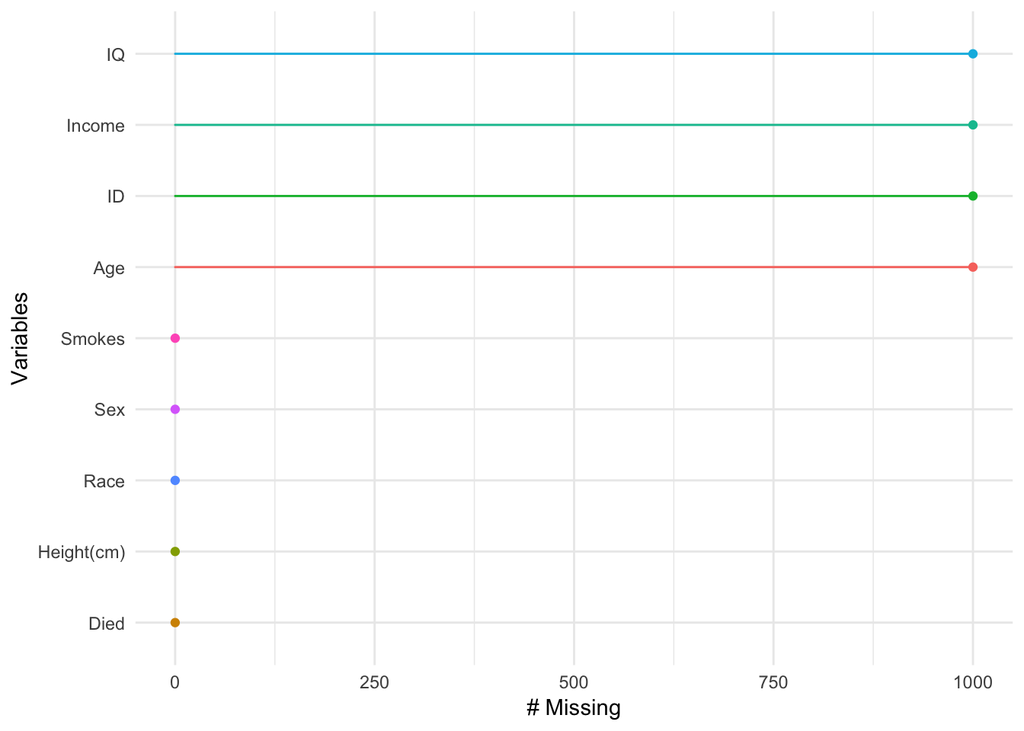

```r
gg_miss_var(typical_data)
```

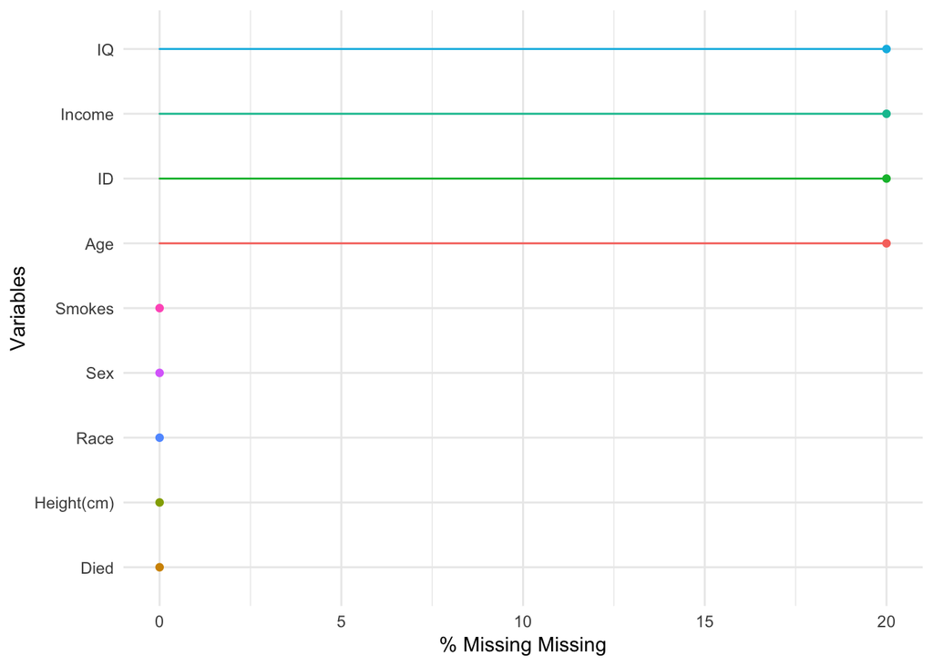

```r
gg_miss_var(typical_data, show_pct = TRUE) # число пропусков в процентах
```

Ещё больше красивых визуализаций — в виньетке пакета [`naniar`](https://cran.r-project.org/web/packages/naniar/vignettes/getting-started-w-naniar.html).

Теперь, зная врага в лицо, приступим к борьбе с ним! Самый простой способ — удалить все строки данных, в которых есть пропуски. Сделаем это командой `drop_na()`.

```r
typical_removed <- drop_na(typical_data)
skim(typical_removed)
```

```
## Skim summary statistics
##  n obs: 2069
##  n variables: 9
##
## Variable type: character
##  variable missing complete    n min max empty n_unique
##        ID       0     2069 2069   4   4     0     2069
##
## Variable type: factor
##  variable missing complete    n n_unique
##      Race       0     2069 2069        8
##       Sex       0     2069 2069        2
##                              top_counts ordered
##  Whi: 1339, His: 336, Bla: 247, Asi: 94   FALSE
##             Fem: 1060, Mal: 1009, NA: 0   FALSE
##
## Variable type: integer
##  variable missing complete    n  mean   sd p0 p25 p50 p75 p100     hist
##       Age       0     2069 2069 27.46 4.62 20  23  27  32   35 ▇▇▇▇▇▇▇▇
##
## Variable type: logical
##  variable missing complete    n mean                       count
##      Died       0     2069 2069 0.49 FAL: 1060, TRU: 1009, NA: 0
##    Smokes       0     2069 2069 0.17  FAL: 1707, TRU: 362, NA: 0
##
## Variable type: numeric
##    variable missing complete    n     mean       sd     p0      p25
##  Height(cm)       0     2069 2069   175.07     9.61 141.5    168.5
##      Income       0     2069 2069 39952.14 28482.09 403.77 18866.16
##          IQ       0     2069 2069    99.7     10.12  66       93
##       p50      p75    p100     hist
##    175.2    181.9    208.1 ▁▁▃▇▇▅▁▁
##  33472.19 53274.31 2e+05   ▇▇▃▂▁▁▁▁
##    100      107      135   ▁▁▃▇▇▃▁▁
```

- Сколько наблюдений осталось?

Команда `replace_na` из пакета `tidyr` позволяет заполнять пропуски любым числом, в том числе средним или медианой. Заполним пропущенные значения в переменной `IQ` минимальным значением, доход `Income` — медианным, `ID` — числом, а возраст `Age` — средним. Эти пожелания передадим аргументу `replace` списком.

```r
typical_replaced <- replace_na(data = typical_data,
  replace = list(IQ =  min(typical_data$IQ, na.rm = TRUE),
  Income = median(typical_data$Income, na.rm = TRUE),
  ID = -1,
  Age = mean(typical_data$Age, na.rm = TRUE)))
skim(typical_replaced)
```

```
## Skim summary statistics
##  n obs: 5000
##  n variables: 9
##
## Variable type: character
##  variable missing complete    n min max empty n_unique
##        ID       0     5000 5000   2   4     0     4001
##
## Variable type: factor
##  variable missing complete    n n_unique
##      Race       0     5000 5000        8
##       Sex       0     5000 5000        2
##                               top_counts ordered
##  Whi: 3196, His: 811, Bla: 612, Asi: 244   FALSE
##              Mal: 2500, Fem: 2500, NA: 0   FALSE
##
## Variable type: logical
##  variable missing complete    n mean                       count
##      Died       0     5000 5000 0.5  FAL: 2518, TRU: 2482, NA: 0
##    Smokes       0     5000 5000 0.18  FAL: 4088, TRU: 912, NA: 0
##
## Variable type: numeric
##    variable missing complete    n     mean       sd     p0      p25
##         Age       0     5000 5000    27.47     4.09  20       24
##  Height(cm)       0     5000 5000   175.31     9.73 141.2    168.6
##      Income       0     5000 5000 38682.42 25671.45 403.77 22639.35
##          IQ       0     5000 5000    92.41    17.26  63       84
##       p50      p75      p100     hist
##     27.47    30        35    ▂▃▃▇▂▂▃▂
##    175.5    182.1     212    ▁▁▅▇▇▃▁▁
##  33128.29 47762.38 208210.62 ▅▇▂▁▁▁▁▁
##     96      105       135    ▆▁▃▇▇▅▁▁
```

- Упражнение 7.
- Удалите все наблюдения с пропусками из данных `airquality`. Сколько наблюдений осталось?
- Заполните пропуски в данных. Для переменной `Ozone` — средним значением, а для `Solar.R` — медианным.
- Проверьте, что всё получилось :)

```r
air_removed <- drop_na(airquality)
skim(air_removed)
```

```
## Skim summary statistics
##  n obs: 111
##  n variables: 6
##
## Variable type: integer
##  variable missing complete   n   mean    sd p0   p25 p50   p75 p100
##       Day       0      111 111  15.95  8.71  1   9    16  22.5   31
##     Month       0      111 111   7.22  1.47  5   6     7   9      9
##     Ozone       0      111 111  42.1  33.28  1  18    31  62    168
##   Solar.R       0      111 111 184.8  91.15  7 113.5 207 255.5  334
##      Temp       0      111 111  77.79  9.53 57  71    79  84.5   97
##      hist
##  ▇▆▆▇▇▇▆▇
##  ▆▂▁▇▁▆▁▇
##  ▇▆▃▂▂▁▁▁
##  ▅▃▃▂▆▇▇▃
##  ▂▃▃▅▇▅▃▂
##
## Variable type: numeric
##  variable missing complete   n mean   sd  p0 p25 p50  p75 p100     hist
##      Wind       0      111 111 9.94 3.56 2.3 7.4 9.7 11.5 20.7 ▂▂▇▇▂▂▁▁
```

```r
air_replaced <- replace_na(data = airquality,
  replace = list(Ozone = mean(airquality$Ozone, na.rm = TRUE),
  Solar.R = median(airquality$Solar.R, na.rm = TRUE)))
skim(air_replaced)
```

```
## Skim summary statistics
##  n obs: 153
##  n variables: 6
##
## Variable type: integer
##  variable missing complete   n  mean   sd p0 p25 p50 p75 p100     hist
##       Day       0      153 153 15.8  8.86  1   8  16  23   31 ▇▇▇▇▆▇▇▇
##     Month       0      153 153  6.99 1.42  5   6   7   8    9 ▇▇▁▇▁▇▁▇
##      Temp       0      153 153 77.88 9.47 56  72  79  85   97 ▂▂▃▆▇▇▃▃
##
## Variable type: numeric
##  variable missing complete   n   mean    sd  p0   p25    p50   p75  p100
##     Ozone       0      153 153  42.13 28.69 1    21    42.13  46   168
##   Solar.R       0      153 153 186.8  88.05 7   120   205    256   334
##      Wind       0      153 153   9.96  3.52 1.7   7.4   9.7   11.5  20.7
##      hist
##  ▅▇▂▂▁▁▁▁
##  ▃▃▃▃▇▇▇▃
##  ▁▃▇▇▅▅▁▁
```

# 5 Кластеризация k-means

Для примера возьмём данные по потреблению протеинов Европе из книги [Practial Machine Learning Cookbook](https://github.com/PacktPublishing/Practical-Machine-Learning-Cookbook/blob/master/Chapter%2003/Data/Europenaprotein.csv). Сначала, как всегда, загрузим их и посмотрим описательные статистики.

```r
protein <- import('Europenaprotein.csv')
skim(protein)
```

```
## Skim summary statistics
##  n obs: 25
##  n variables: 10
##
## Variable type: character
##  variable missing complete  n min max empty n_unique
##   Country       0       25 25   2  14     0       25
##
## Variable type: numeric
##   variable missing complete  n  mean    sd   p0  p25  p50  p75 p100
##    Cereals       0       25 25 32.25 10.97 18.6 24.3 28   40.1 56.7
##       Eggs       0       25 25  2.94  1.12  0.5  2.7  2.9  3.7  4.7
##       Fish       0       25 25  4.28  3.4   0.2  2.1  3.4  5.8 14.2
##     Fr&Veg       0       25 25  4.14  1.8   1.4  2.9  3.8  4.9  7.9
##       Milk       0       25 25 17.11  7.11  4.9 11.1 17.6 23.3 33.7
##       Nuts       0       25 25  3.07  1.99  0.7  1.5  2.4  4.7  7.8
##    RedMeat       0       25 25  9.83  3.35  4.4  7.8  9.5 10.6 18
##     Starch       0       25 25  4.28  1.63  0.6  3.1  4.7  5.7  6.5
##  WhiteMeat       0       25 25  7.9   3.69  1.4  4.9  7.8 10.8 14
##      hist
##  ▅▇▁▂▂▁▁▂
##  ▁▂▁▁▇▂▃▂
##  ▅▇▂▃▁▂▁▁
##  ▅▇▇▇▂▁▆▃
##  ▂▇▂▇▃▇▁▁
##  ▇▇▁▃▂▆▁▁
##  ▂▆▇▆▁▃▁▂
##  ▃▁▅▃▆▇▆▇
##  ▁▃▇▁▁▇▃▃
```

- Есть ли в данных пропущенные наблюдения?

## 5.1 Масштабирование переменных

Для того, чтобы сравнивать переменные с разными единицами измерения, их масштабируют: вычитают среднее и делят на оценку стандартного отклонения.

$$x_i^* = (x_i - \bar x) / \hat \sigma_x,$$
где $\bar x = \frac{x_1 + x_2 + \ldots + x_n}{n}$, а
$$\hat\sigma_x = \frac{(x_1 - \bar x)^2 + \ldots + (x_n - \bar x)^2}{n-1}.$$

Отмасштабируем данные с помощью встроенной функции `scale()`. Поскольку она может работать только с числами, первый столбец `Country` ей передавать не нужно. Результат сохраним в таблице `protein_stand`.

```r
protein_stand <- mutate_if(protein, is.numeric, ~ as.vector(scale(.)))
skim(protein_stand)
```

```
## Skim summary statistics
##  n obs: 25
##  n variables: 10
##
## Variable type: character
##  variable missing complete  n min max empty n_unique
##   Country       0       25 25   2  14     0       25
##
## Variable type: numeric
##   variable missing complete  n     mean sd    p0   p25    p50  p75 p100
##    Cereals       0       25 25  2.6e-16  1 -1.24 -0.72 -0.39  0.72 2.23
##       Eggs       0       25 25  5.5e-17  1 -2.18 -0.21 -0.032 0.68 1.58
##       Fish       0       25 25  6.3e-17  1 -1.2  -0.64 -0.26  0.45 2.91
##     Fr&Veg       0       25 25 -6.6e-17  1 -1.52 -0.69 -0.19  0.42 2.09
##       Milk       0       25 25 -2.1e-16  1 -1.72 -0.85  0.069 0.87 2.33
##       Nuts       0       25 25 -1.1e-17  1 -1.19 -0.79 -0.34  0.82 2.38
##    RedMeat       0       25 25  1.8e-16  1 -1.62 -0.61 -0.098 0.23 2.44
##     Starch       0       25 25  1.7e-16  1 -2.25 -0.72  0.26  0.87 1.36
##  WhiteMeat       0       25 25  2.3e-17  1 -1.76 -0.81 -0.026 0.79 1.65
##      hist
##  ▅▇▁▂▂▁▁▂
##  ▁▂▁▁▇▂▃▂
##  ▅▇▂▃▁▂▁▁
##  ▅▇▇▇▂▁▆▃
##  ▂▇▂▇▃▇▁▁
##  ▇▇▁▃▂▆▁▁
##  ▂▆▇▆▁▃▁▂
##  ▃▁▅▃▆▇▆▇
##  ▁▃▇▁▁▇▃▃
```

Дополнение в виде функции `as.vector` нужно потому, что функция `scale` возвращает матрицу, а каждый столбец должен быть вектором :)

- Посмотрите на описательные статистики. Что стало со средним значением и стандартным отклонением переменных?
- Упражнение 8.

Хитрая исследовательница Даша хочет возвести в квадрат сразу все числовые столбцы в наборе данных `diamonds`. Помогите Даше возвести столбцы в квадрат!

```r
diamonds2 <- mutate_if(diamonds, is.numeric, ~ .^2)
```

- Упражнение 9.
- Посмотрите на описательные статистики встроенного набора данных об арестах в США.
- Отмасштабируйте данные и сохраните их в таблицу `usa_stand`.
- Проверьте, что всё получилось :)

```r
usa <- USArrests
skim(usa)
```

```
## Skim summary statistics
##  n obs: 50
##  n variables: 4
##
## Variable type: integer
##  variable missing complete  n   mean    sd p0   p25 p50    p75 p100
##   Assault       0       50 50 170.76 83.34 45 109   159 249     337
##  UrbanPop       0       50 50  65.54 14.47 32  54.5  66  77.75   91
##      hist
##  ▇▇▅▇▂▇▅▂
##  ▂▃▆▅▇▆▇▃
##
## Variable type: numeric
##  variable missing complete  n  mean   sd  p0   p25   p50   p75 p100
##    Murder       0       50 50  7.79 4.36 0.8  4.08  7.25 11.25 17.4
##      Rape       0       50 50 21.23 9.37 7.3 15.08 20.1  26.17 46
##      hist
##  ▇▇▇▇▃▇▁▃
##  ▆▇▇▆▃▂▂▂
```

```r
usa_stand <- mutate_if(usa , is.numeric, ~ as.vector(scale(.)))
glimpse(usa_stand)
```

```
## Observations: 50
## Variables: 4
## $ Murder   <dbl> 1.24256408, 0.50786248, 0.07163341, 0.23234938, 0.278...
## $ Assault  <dbl> 0.78283935, 1.10682252, 1.47880321, 0.23086801, 1.262...
## $ UrbanPop <dbl> -0.52090661, -1.21176419, 0.99898006, -1.07359268, 1....
## $ Rape     <dbl> -0.003416473, 2.484202941, 1.042878388, -0.184916602,...
```

Выполним кластеризацию методом k-средних с помощью функции `kmeans`. Название страны не используется для кластеризации, но нужно для меток на графиках. Поэтому мы уберем столбец `Country` из набора данных и превратим его в метки строк.

В качестве аргументов укажем отмасштабированные данные `protein_no_country` и количество кластеров `centers`. Пока мы не знаем, как выбирать оптимальное количество кластеров, поэтому предположим, что их три. Сохраним результат этого действия в список `k_means_protein`.

```r
protein_no_country <- protein_stand %>% column_to_rownames(var = 'Country')
k_means_protein <- kmeans(protein_no_country, centers = 3)
k_means_protein
```

```
## K-means clustering with 3 clusters of sizes 8, 15, 2
##
## Cluster means:
##      RedMeat  WhiteMeat       Eggs       Milk       Fish    Cereals
## 1 -0.6096362 -0.6553728 -0.8934192 -0.7300065 -0.6859595  1.2382474
## 2  0.4517373  0.5063957  0.5762263  0.5837801  0.1183432 -0.6100043
## 3 -0.9494848 -1.1764767 -0.7480204 -1.4583242  1.8562639 -0.3779572
##       Starch       Nuts      Fr&Veg
## 1 -0.8956083  1.0401967 -0.06153324
## 2  0.3533068 -0.7043759 -0.21952398
## 3  0.9326321  1.1220326  1.89256278
##
## Clustering vector:
##        Albania        Austria        Belgium       Bulgaria Czechoslovakia
##              1              2              2              1              2
##        Denmark      E Germany        Finland         France         Greece
##              2              2              2              2              1
##        Hungary        Ireland          Italy    Netherlands         Norway
##              1              2              1              2              2
##         Poland       Portugal        Romania          Spain         Sweden
##              2              3              1              3              2
##    Switzerland             UK           USSR      W Germany     Yugoslavia
##              2              2              1              2              1
##
## Within cluster sum of squares by cluster:
## [1] 39.167085 62.969328  4.300578
##  (between_SS / total_SS =  50.7 %)
##
## Available components:
##
## [1] "cluster"      "centers"      "totss"        "withinss"
## [5] "tot.withinss" "betweenss"    "size"         "iter"
## [9] "ifault"
```

В списке `k_means_protein` лежит куча разной информации! Посмотрим на содержимое списка `k_means_protein` командой `attributes()`.

```r
attributes(k_means_protein)
```

```
## $names
## [1] "cluster"      "centers"      "totss"        "withinss"
## [5] "tot.withinss" "betweenss"    "size"         "iter"
## [9] "ifault"
##
## $class
## [1] "kmeans"
```

Помните также, что в Rstudio можно кликнуть на лупу справа от `k_means_protein` во вкладке `Environment`.

Теперь, зная, что искать, мы можем посмотреть, например, на координаты центра кластеров или количество объектов в каждом из них.

```r
k_means_protein$centers
```

```
##      RedMeat  WhiteMeat       Eggs       Milk       Fish    Cereals
## 1 -0.6096362 -0.6553728 -0.8934192 -0.7300065 -0.6859595  1.2382474
## 2  0.4517373  0.5063957  0.5762263  0.5837801  0.1183432 -0.6100043
## 3 -0.9494848 -1.1764767 -0.7480204 -1.4583242  1.8562639 -0.3779572
##       Starch       Nuts      Fr&Veg
## 1 -0.8956083  1.0401967 -0.06153324
## 2  0.3533068 -0.7043759 -0.21952398
## 3  0.9326321  1.1220326  1.89256278
```

```r
k_means_protein$cluster
```

```
##        Albania        Austria        Belgium       Bulgaria Czechoslovakia
##              1              2              2              1              2
##        Denmark      E Germany        Finland         France         Greece
##              2              2              2              2              1
##        Hungary        Ireland          Italy    Netherlands         Norway
##              1              2              1              2              2
##         Poland       Portugal        Romania          Spain         Sweden
##              2              3              1              3              2
##    Switzerland             UK           USSR      W Germany     Yugoslavia
##              2              2              1              2              1
```

```r
k_means_protein$size
```

```
## [1]  8 15  2
```

Другой способ структурировать вывод `kmeans` — использовать команду `tidy` из пакета `broom`.

```r
tidy(k_means_protein)
```

```
##           x1         x2         x3         x4         x5         x6
## 1 -0.6096362 -0.6553728 -0.8934192 -0.7300065 -0.6859595  1.2382474
## 2  0.4517373  0.5063957  0.5762263  0.5837801  0.1183432 -0.6100043
## 3 -0.9494848 -1.1764767 -0.7480204 -1.4583242  1.8562639 -0.3779572
##           x7         x8          x9 size  withinss cluster
## 1 -0.8956083  1.0401967 -0.06153324    8 39.167085       1
## 2  0.3533068 -0.7043759 -0.21952398   15 62.969328       2
## 3  0.9326321  1.1220326  1.89256278    2  4.300578       3
```

Первые девять неназванных переменных — центры кластеров по каждой переменной.

- Упражнение 10.

Кластеризуйте отмасштабированные данные по арестам в США. В выборе числа кластеров доверьтесь интуиции.

```r
k_means_usa <- kmeans(usa_stand, centers = 3)
```

Осталось только визуализировать результаты! Для этого будем использовать команду `fviz_cluster()` из пакета `factoextra`. Её аргументы — результат кластеризации `k_means_protein`, исходные данные и ещё куча настроек вроде размера точек и цвета наблюдений-выбросов. Мы только попросим выделять цветом кластеры по их границам и укажем аргумент `ellipse.type = 'convex'`.

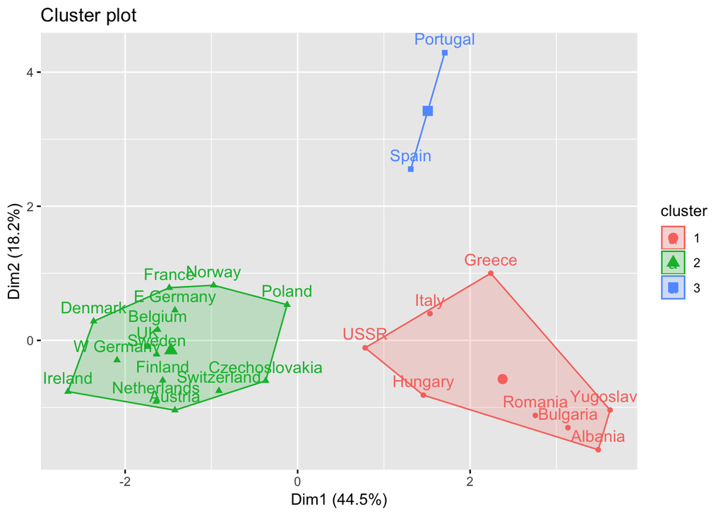

```r
fviz_cluster(object = k_means_protein, data = protein_no_country,
             ellipse.type = 'convex')
```

- Упражнение 11.

Визуализируйте результаты кластеризации данных по арестам `k_means_usa`.

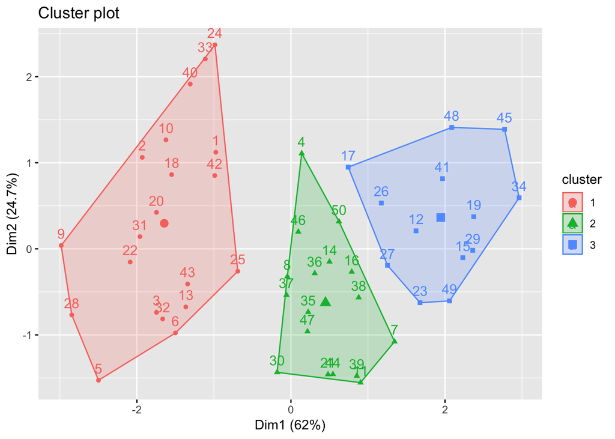

```r
fviz_cluster(object = k_means_usa, data = usa_stand, ellipse.type = 'convex')
```

- Пересекаются ли кластеры?
- Разумно ли изменить количество кластеров?

Как понять, сколько кластеров брать оптимально? Один из способов сделать это — воспользоваться командой `fviz_nbclust` из пакета `factoextra`.

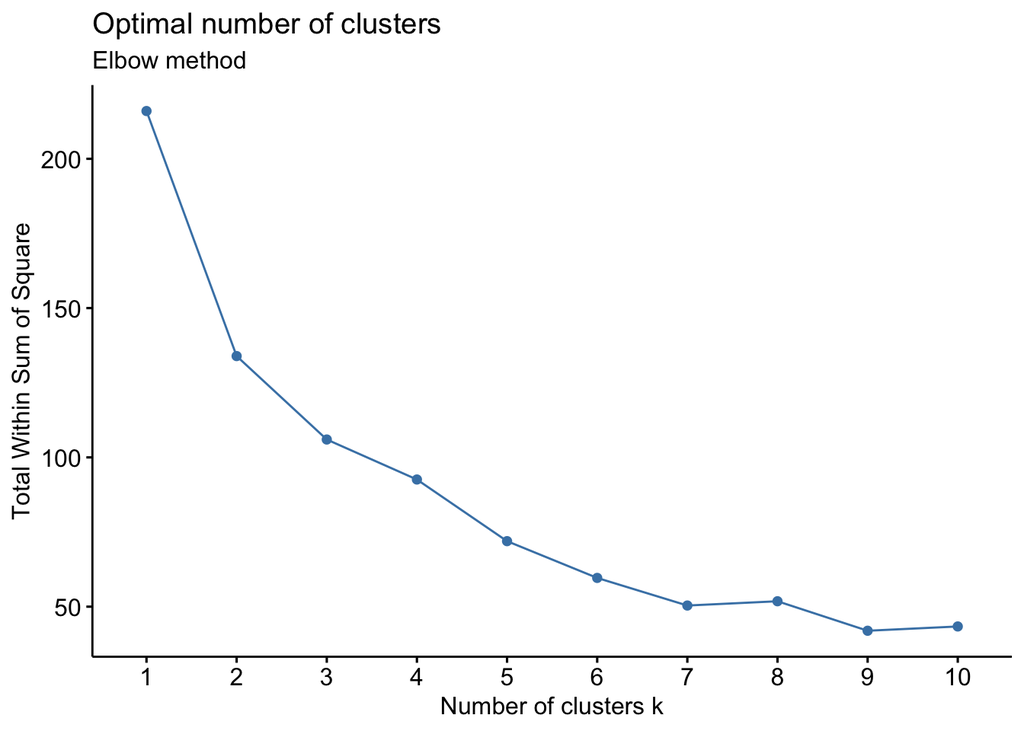

```r
g1 <- fviz_nbclust(protein_no_country, kmeans, method = 'wss') +
  labs(subtitle = 'Elbow method')
g1
```

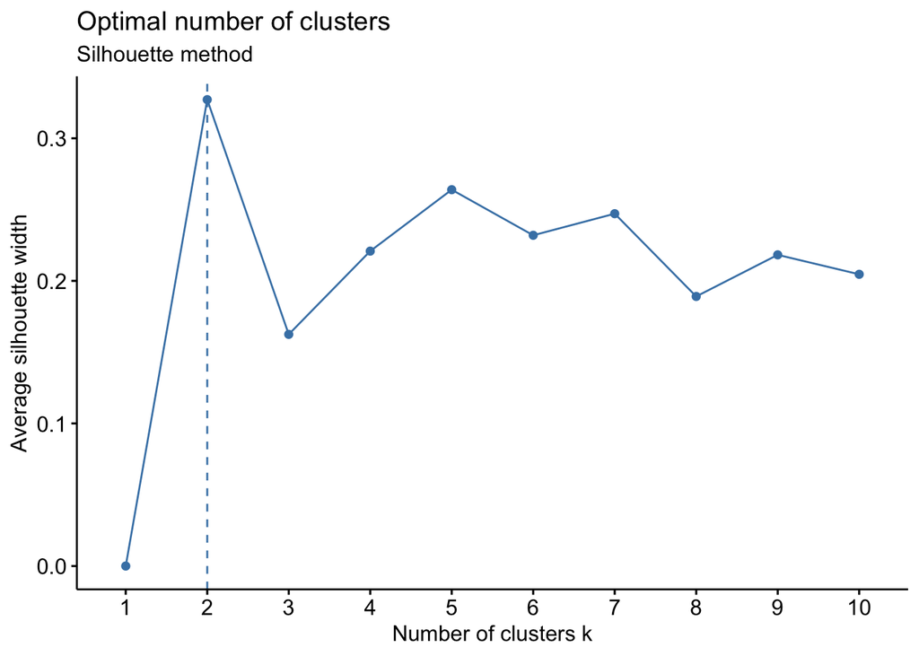

```r
g2 <- fviz_nbclust(protein_no_country, kmeans, method = 'silhouette') +
  labs(subtitle = 'Silhouette method')
g2
```

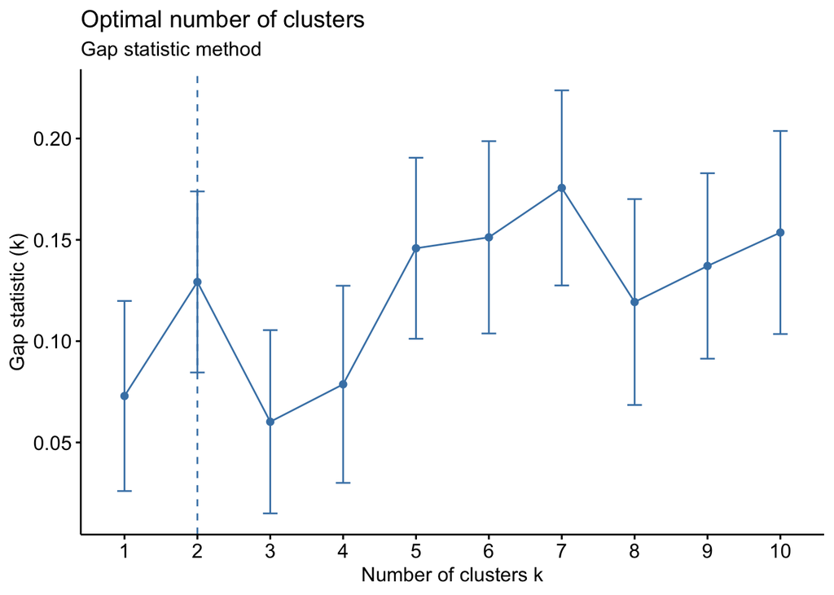

```r
g3 <- fviz_nbclust(protein_no_country, kmeans, method = 'gap_stat') +
  labs(subtitle = 'Gap statistic method')
g3
```

С помощью хитрого пакета Томаса располагать графики легко! Попробуйте!

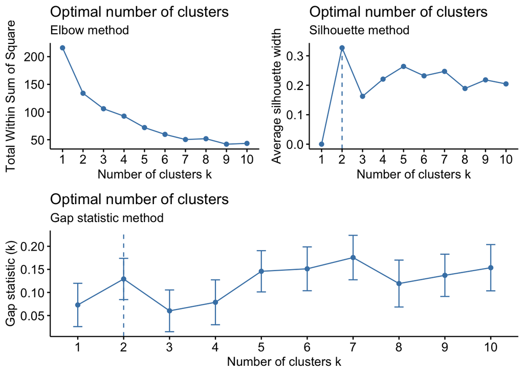

```r
(g1 + g2) / g3
```

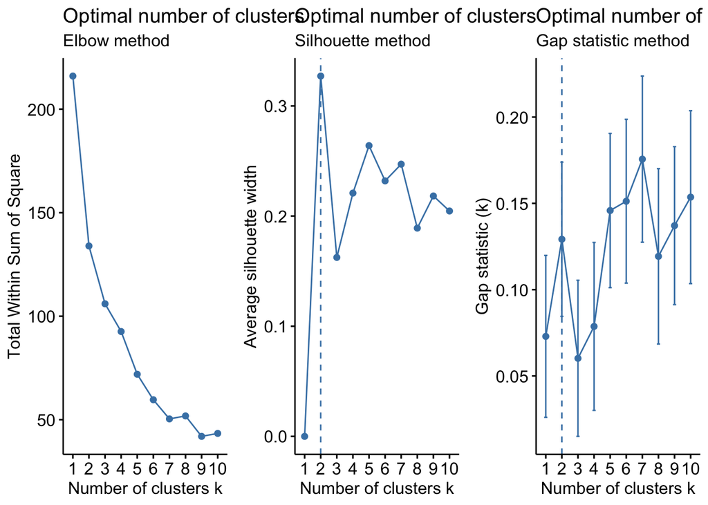

```r
g1 + g2 + g3
```

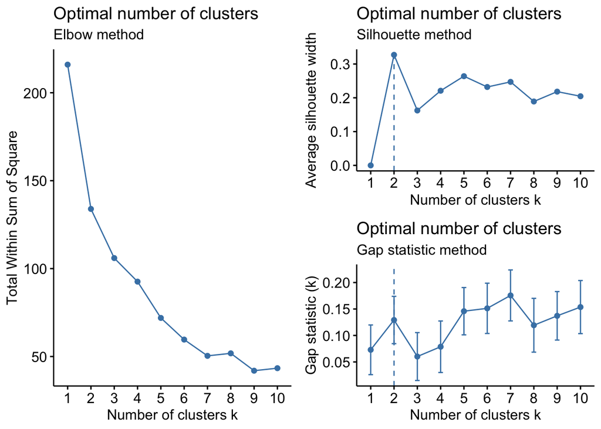

```r
g1 + (g2 / g3)
```

- В чём разница?
- Как расположит графики команда `g1 / (g2 + g3)`?
- Упражнение 12.

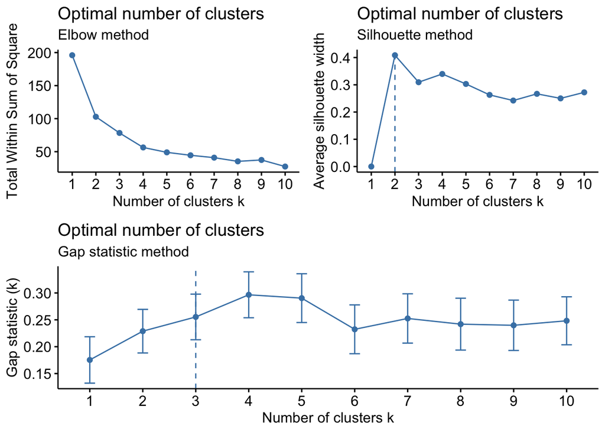

```r
p1 <- fviz_nbclust(usa_stand, kmeans, method = 'wss') +
  labs(subtitle = 'Elbow method')
p2 <- fviz_nbclust(usa_stand, kmeans, method = 'silhouette') +
  labs(subtitle = 'Silhouette method')
p3 <- fviz_nbclust(usa_stand, kmeans, method = 'gap_stat') +
  labs(subtitle = 'Gap statistic method')
(p1 + p2) / p3
```

Метки кластерам легко добавить к исходным данным:

```r
protein_plus <- mutate(protein, cluster = k_means_protein$cluster)
glimpse(protein_plus)
```

```
## Observations: 25
## Variables: 11
## $ Country   <chr> "Albania", "Austria", "Belgium", "Bulgaria", "Czecho...
## $ RedMeat   <dbl> 10.1, 8.9, 13.5, 7.8, 9.7, 10.6, 8.4, 9.5, 18.0, 10....
## $ WhiteMeat <dbl> 1.4, 14.0, 9.3, 6.0, 11.4, 10.8, 11.6, 4.9, 9.9, 3.0...
## $ Eggs      <dbl> 0.5, 4.3, 4.1, 1.6, 2.8, 3.7, 3.7, 2.7, 3.3, 2.8, 2....
## $ Milk      <dbl> 8.9, 19.9, 17.5, 8.3, 12.5, 25.0, 11.1, 33.7, 19.5, ...
## $ Fish      <dbl> 0.2, 2.1, 4.5, 1.2, 2.0, 9.9, 5.4, 5.8, 5.7, 5.9, 0....
## $ Cereals   <dbl> 42.3, 28.0, 26.6, 56.7, 34.3, 21.9, 24.6, 26.3, 28.1...
## $ Starch    <dbl> 0.6, 3.6, 5.7, 1.1, 5.0, 4.8, 6.5, 5.1, 4.8, 2.2, 4....
## $ Nuts      <dbl> 5.5, 1.3, 2.1, 3.7, 1.1, 0.7, 0.8, 1.0, 2.4, 7.8, 5....
## $ `Fr&Veg`  <dbl> 1.7, 4.3, 4.0, 4.2, 4.0, 2.4, 3.6, 1.4, 6.5, 6.5, 4....
## $ cluster   <int> 1, 2, 2, 1, 2, 2, 2, 2, 2, 1, 1, 2, 1, 2, 2, 2, 3, 1...
```

# 6 Иерархическая кластеризация

Другой способ разбить данные на группы — иерархическая кластеризация. Но, в отличие от метода k-средних, она работает с матрицей расстояний, поэтому первым делом посчитаем её! Для этого будем использовать функцию `dist()`. Передадим ей стандартизированные данные и укажем явно, как считать расстояния с помощью аргумента `method`. О всех остальных опциях можно узнать в справке.

```r
protein_dist <- dist(protein_no_country, method = 'euclidian')
```

Расстояния тоже можно визуализировать! Сделаем это командой `fviz_dist` из пакета `factoextra`.

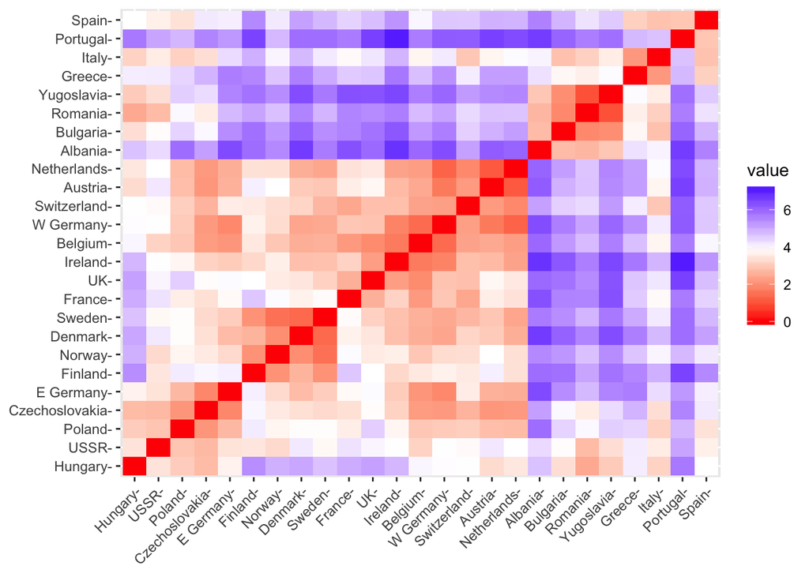

```r
fviz_dist(protein_dist)
```

- Упражнение 13.

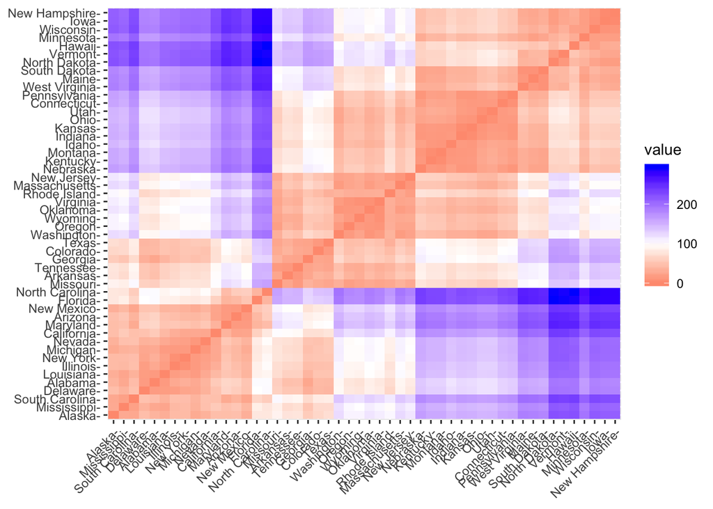

```r
usa_dist <- dist(usa, method = 'euclidian')
fviz_dist(usa_dist)
```

Полученную матрицу расстояний можно передадать функции `hclust()`, которая кластеризует данные. Однако в пакете `factoextra` есть функция `hcut()`, которая работает с исходными данными. Будем использовать её и попросим выделить четыре кластера в аргументе `k`.

```r
protein_hcl <- hcut(protein_no_country, k = 4)
```

С помощью функции `fviz_dend` визуализируем результат кластеризации. Укажем несколько аргументов, чтобы сделать дендрограмму красивее, а полный перечень найдётся в справке.

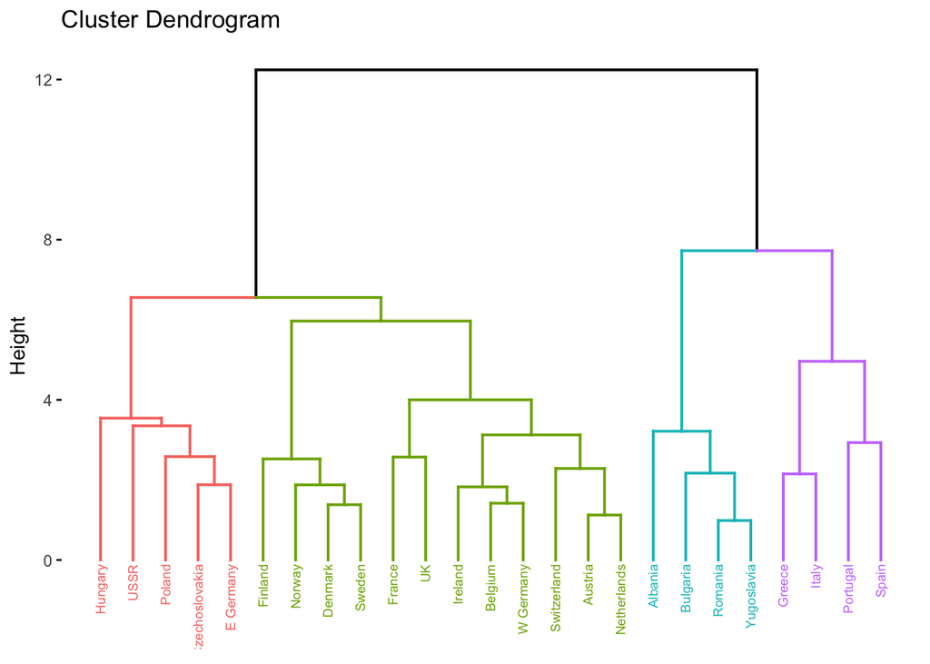

```r
fviz_dend(protein_hcl,
          cex = 0.5, # размер подписи
          color_labels_by_k = TRUE) # цвет подписей по группам
```

Выявленные кластеры можно добавить к исходным данным!

```r
protein_plus2 <- mutate(protein, cluster = protein_hcl$cluster)
glimpse(protein_plus2)
```

```
## Observations: 25
## Variables: 11
## $ Country   <chr> "Albania", "Austria", "Belgium", "Bulgaria", "Czecho...
## $ RedMeat   <dbl> 10.1, 8.9, 13.5, 7.8, 9.7, 10.6, 8.4, 9.5, 18.0, 10....
## $ WhiteMeat <dbl> 1.4, 14.0, 9.3, 6.0, 11.4, 10.8, 11.6, 4.9, 9.9, 3.0...
## $ Eggs      <dbl> 0.5, 4.3, 4.1, 1.6, 2.8, 3.7, 3.7, 2.7, 3.3, 2.8, 2....
## $ Milk      <dbl> 8.9, 19.9, 17.5, 8.3, 12.5, 25.0, 11.1, 33.7, 19.5, ...
## $ Fish      <dbl> 0.2, 2.1, 4.5, 1.2, 2.0, 9.9, 5.4, 5.8, 5.7, 5.9, 0....
## $ Cereals   <dbl> 42.3, 28.0, 26.6, 56.7, 34.3, 21.9, 24.6, 26.3, 28.1...
## $ Starch    <dbl> 0.6, 3.6, 5.7, 1.1, 5.0, 4.8, 6.5, 5.1, 4.8, 2.2, 4....
## $ Nuts      <dbl> 5.5, 1.3, 2.1, 3.7, 1.1, 0.7, 0.8, 1.0, 2.4, 7.8, 5....
## $ `Fr&Veg`  <dbl> 1.7, 4.3, 4.0, 4.2, 4.0, 2.4, 3.6, 1.4, 6.5, 6.5, 4....
## $ cluster   <int> 1, 2, 2, 1, 3, 2, 3, 2, 2, 4, 3, 2, 4, 2, 2, 3, 4, 1...
```

- Упражнение 14.
- Сделайте иерархическую кластеризацию с четыремя группами на данных об арестах.
- Визуализируйте результат кластеризации и сделайте подписи цветными.

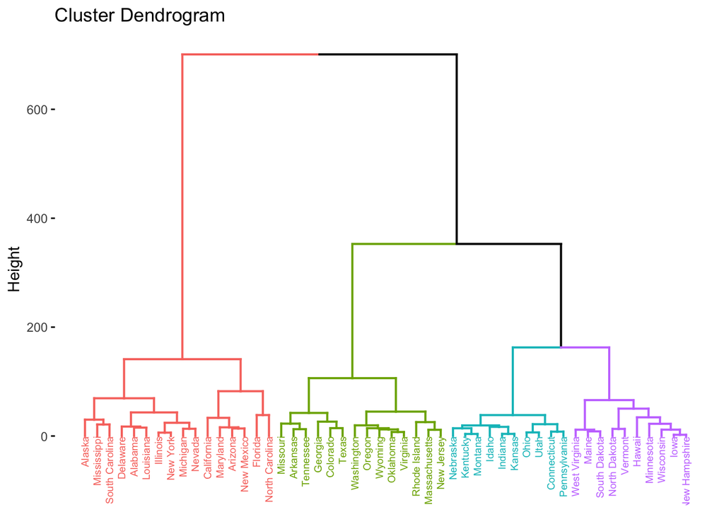

```r
usa_hcl <- hcut(usa, k = 4)
fviz_dend(usa_hcl,
          cex = 0.5, # размер подписи
          color_labels_by_k = TRUE) # цвет подписей по группам
```

Иерархичская кластеризация полезна и для визуализаций корреляций. Если в функции `corrplot()` из одноимённого пакета указать аргумента `order = hclust`, то мы получим сгруппированные по кластерам переменные. Для красоты добавим ещё один аргумент — `addrect = 3`. Он обведёт прямоугольниками указанное число кластеров.

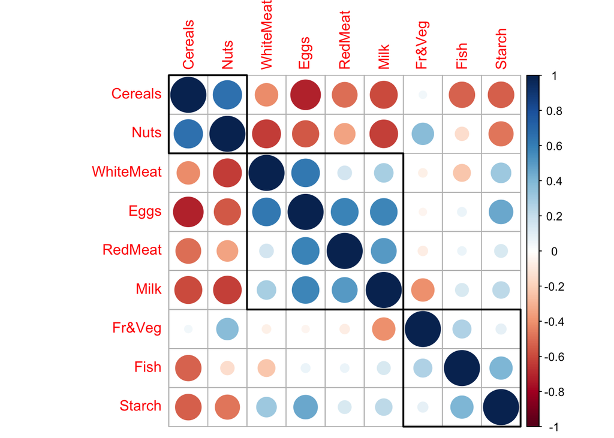

```r
protein_cor <- cor(protein_no_country)
corrplot(protein_cor, order = 'hclust', addrect = 3)
```

- Упражнение 15.

Визуализируйте корреляции в данных об арестах `usa` и сгруппируйте их по двум кластерам. Замените кружочки на квадраты, передав аргументу `method` значение `shade`.

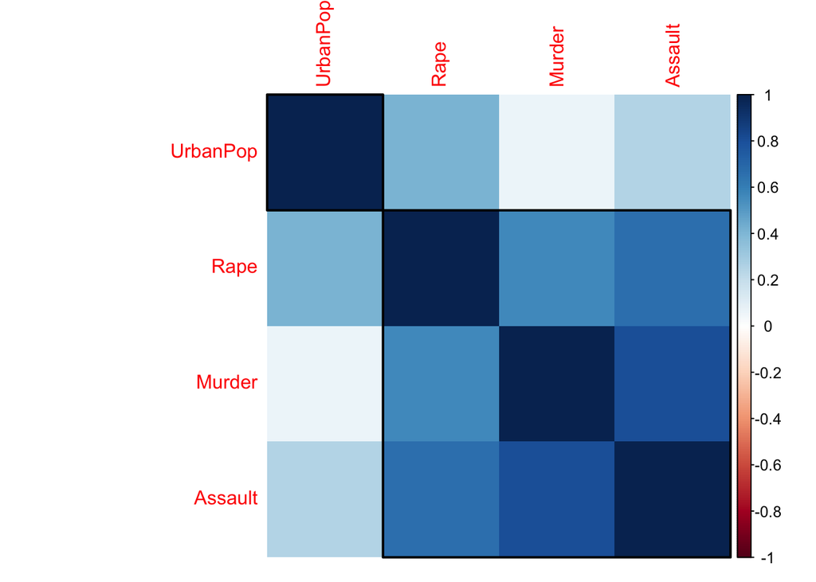

```r
usa_cor <- cor(usa)
corrplot(usa_cor, order = 'hclust', addrect = 2, method = 'shade')
```

- Упражнение 16.

```r
usa_plus2 <- mutate(usa, cluster = TRUE)
glimpse(usa_plus2)
```

```
## Observations: 50
## Variables: 5
## $ Murder   <dbl> 13.2, 10.0, 8.1, 8.8, 9.0, 7.9, 3.3, 5.9, 15.4, 17.4,...
## $ Assault  <int> 236, 263, 294, 190, 276, 204, 110, 238, 335, 211, 46,...
## $ UrbanPop <int> 58, 48, 80, 50, 91, 78, 77, 72, 80, 60, 83, 54, 83, 6...
## $ Rape     <dbl> 21.2, 44.5, 31.0, 19.5, 40.6, 38.7, 11.1, 15.8, 31.9,...
## $ cluster  <lgl> TRUE, TRUE, TRUE, TRUE, TRUE, TRUE, TRUE, TRUE, TRUE,...
```

Визуализации [кластеров в известных наборах данных] (https://cran.r-project.org/web/packages/dendextend/vignettes/Cluster_Analysis.html)

Ура! :)